# Generalized linear models

Gerko Vink

Statistical Programming with R

## Packages and functions used

```r
library(magrittr) # pipes
library(DAAG) # data sets and functions
```

- `glm()` Generalized linear models
- `predict()` Obtain predictions based on a model
- `confint()` Obtain confidence intervals for model parameters
- `coef()` Obtain a model’s coefficients
- `DAAG::CVbinary()` Cross-validation for regression with a binary response

# Generalized linear models

## GLM’s

We knew
$$y=\alpha+\beta x+\epsilon$$

Now we consider
$$\mathbb{E}[y] = \alpha + \beta x$$

They’re the same. Different notation, different framework.

The upside is that we can now use a function for the expectation $\mathbb{E}$ to allow for transformations. This would enable us to change $\mathbb{E}[y]$ such that $f(\mathbb{E}[y])$ has a linear relation with $x$.

The function $f()$ we call the `link function`. This function tranforms the scale of the response/outcome to the scale of the linear predictor.

Examples: $f(x) = x, \\ f(x) = 1/x, \\ f(x) = \log(x), \\ f(x) = \log(x/(1-x)).$

## Link functions

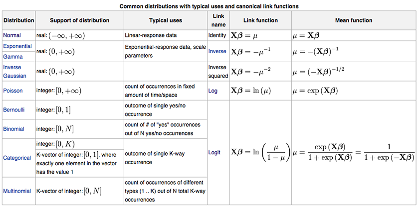

Overview of link functions, bluntly borrowed from Wikipedia

## GLM’s continued

Remember that
$$y=\alpha+\beta x+\epsilon,$$

and that
$$\mathbb{E}[y] = \alpha + \beta x.$$

As a result
$$y = \mathbb{E}[y] + \epsilon.$$

and residuals do not need to be normal (heck, $y$ probably isn’t, so why should $\epsilon$ be?)

## Logit

$$\text{logit}(p) = \log(\frac{p}{1-p}) = \log(p) - \log(1-p)$$

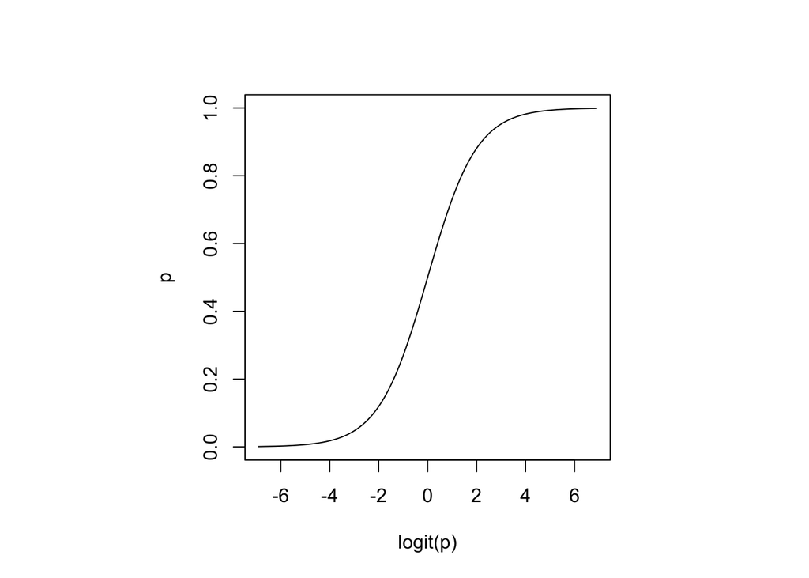

## Logit continued

Logit models work on the $\log(\text{odds})$ scale

$$\log(\text{odds}) = \log(\frac{p}{1-p}) = \log(p) - \log(1-p) = \text{logit}(p)$$

The logit of the probability is the log of the odds.

Logistic regression allows us to model the $\log(\text{odds})$ as a function of other, linear predictors.

## $\log(\text{odds})$ explained

```r
logodds <- rep(NA, 1001)
for(i in 0:1000){
  p <- i / 1000
  logodds[i + 1] <- log(p / (1 - p))
}
head(logodds)
```

```
## [1]      -Inf -6.906755 -6.212606 -5.806138 -5.517453 -5.293305
```

```r
tail(logodds)
```

```
## [1] 5.293305 5.517453 5.806138 6.212606 6.906755      Inf
```

## $\log(\text{odds})$ explained

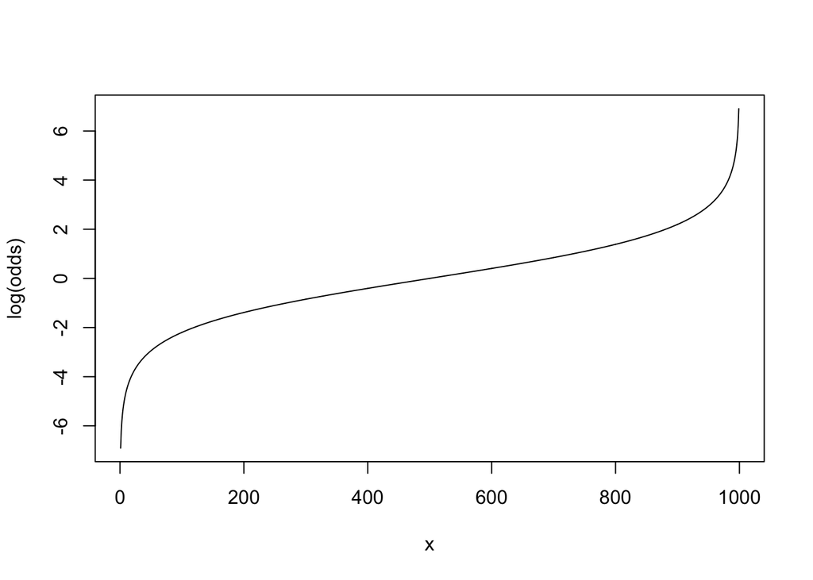

```r
plot(0:1000, logodds, xlab = "x", ylab = "log(odds)", type = "l")
```

## logit$^{-1}$ explained

```r
invlogit <- exp(logodds) / (1 + exp(logodds))
invlogit %>% head()
```

```
## [1] 0.000 0.001 0.002 0.003 0.004 0.005
```

```r
invlogit %>% head()
```

```
## [1] 0.000 0.001 0.002 0.003 0.004 0.005
```

## logit$^{-1}$ explained

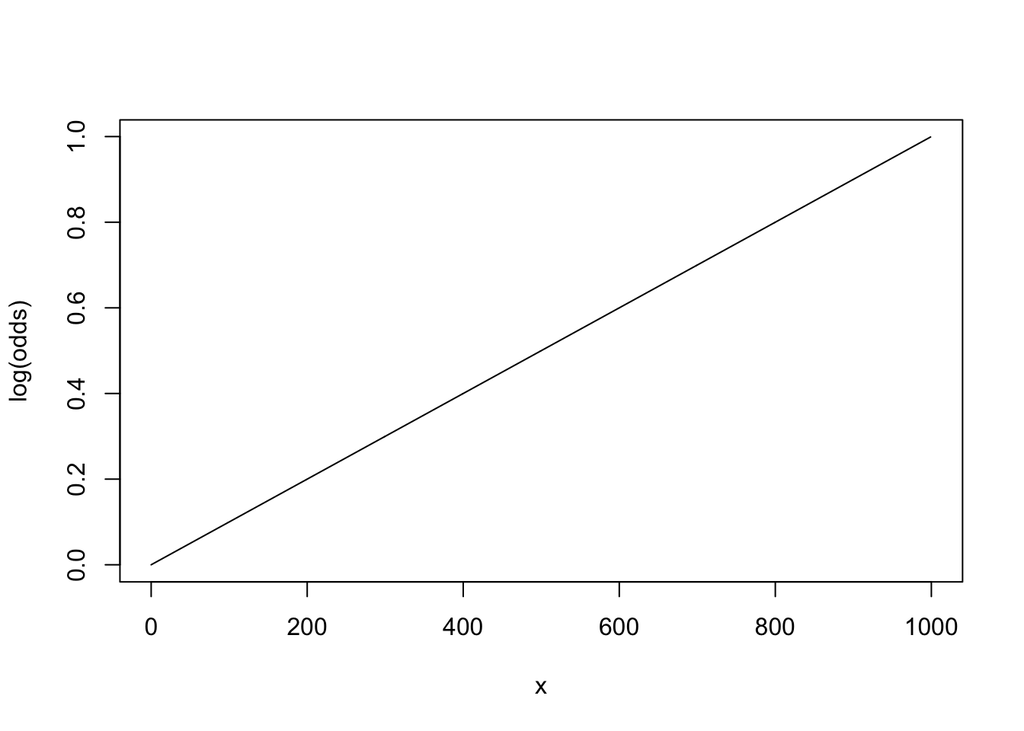

```r
plot(0:1000, invlogit, xlab = "x", ylab = "log(odds)", type = "l")
```

# Logistic regression

## Logistic regression

With linear regression we had the `Sum of Squares (SS)`. Its logistic counterpart is the `Deviance (D)`.

- Deviance is the fit of the observed values to the expected values.

With logistic regression we aim to maximize the `likelihood`, which is equivalent to minimizing the deviance.

The likelihood is the (joint) probability of the observed values, given the current model parameters.

In normally distributed data: $\text{SS}=\text{D}$.

## Logistic regression

```r
anesthetic %>% head(n = 18)
```

```
##    move conc    logconc nomove
## 1     0  1.0  0.0000000      1
## 2     1  1.2  0.1823216      0
## 3     0  1.4  0.3364722      1
## 4     1  1.4  0.3364722      0
## 5     1  1.2  0.1823216      0
## 6     0  2.5  0.9162907      1
## 7     0  1.6  0.4700036      1
## 8     1  0.8 -0.2231436      0
## 9     0  1.6  0.4700036      1
## 10    1  1.4  0.3364722      0
## 11    1  0.8 -0.2231436      0
## 12    0  1.6  0.4700036      1
## 13    0  2.5  0.9162907      1
## 14    0  1.4  0.3364722      1
## 15    0  1.6  0.4700036      1
## 16    0  1.4  0.3364722      1
## 17    0  1.4  0.3364722      1
## 18    1  0.8 -0.2231436      0
```

## Logistic regression

```r
anesthetic %$% glm(nomove ~ conc, family = binomial(link="logit")) %>% summary()
```

```
##
## Call:
## glm(formula = nomove ~ conc, family = binomial(link = "logit"))
##
## Deviance Residuals:
##      Min        1Q    Median        3Q       Max
## -1.76666  -0.74407   0.03413   0.68666   2.06900
##
## Coefficients:
##             Estimate Std. Error z value Pr(>|z|)
## (Intercept)   -6.469      2.418  -2.675  0.00748 **
## conc           5.567      2.044   2.724  0.00645 **
## ---
## Signif. codes:  0 '***' 0.001 '**' 0.01 '*' 0.05 '.' 0.1 ' ' 1
##
## (Dispersion parameter for binomial family taken to be 1)
##
##     Null deviance: 41.455  on 29  degrees of freedom
## Residual deviance: 27.754  on 28  degrees of freedom
## AIC: 31.754
##
## Number of Fisher Scoring iterations: 5
```

## A different approach

```r
anestot <- aggregate(anesthetic[, c("move","nomove")],
                     by = list(conc = anesthetic$conc), FUN = sum)
anestot
```

```
##   conc move nomove
## 1  0.8    6      1
## 2  1.0    4      1
## 3  1.2    2      4
## 4  1.4    2      4
## 5  1.6    0      4
## 6  2.5    0      2
```

## A different approach

```r
anestot$total <- apply(anestot[, c("move","nomove")], 1 , sum)
anestot$prop <- anestot$nomove / anestot$total
anestot
```

```
##   conc move nomove total      prop
## 1  0.8    6      1     7 0.1428571
## 2  1.0    4      1     5 0.2000000
## 3  1.2    2      4     6 0.6666667
## 4  1.4    2      4     6 0.6666667
## 5  1.6    0      4     4 1.0000000
## 6  2.5    0      2     2 1.0000000
```

## A different approach

```r
anestot %$% glm(prop ~ conc, family = binomial(link="logit"), weights = total) %>%
  summary()
```

```
##
## Call:
## glm(formula = prop ~ conc, family = binomial(link = "logit"),
##     weights = total)
##
## Deviance Residuals:
##        1         2         3         4         5         6
##  0.20147  -0.45367   0.56890  -0.70000   0.81838   0.04826
##
## Coefficients:
##             Estimate Std. Error z value Pr(>|z|)
## (Intercept)   -6.469      2.419  -2.675  0.00748 **
## conc           5.567      2.044   2.724  0.00645 **
## ---
## Signif. codes:  0 '***' 0.001 '**' 0.01 '*' 0.05 '.' 0.1 ' ' 1
##
## (Dispersion parameter for binomial family taken to be 1)
##
##     Null deviance: 15.4334  on 5  degrees of freedom
## Residual deviance:  1.7321  on 4  degrees of freedom
## AIC: 13.811
##
## Number of Fisher Scoring iterations: 5
```

## Logistic multiple regression

Always try to make the relation as linear as possible

- after all you are assessing a linear model.

Do not forget that you use transformations to “make” things more linear

## Logistic multiple regression

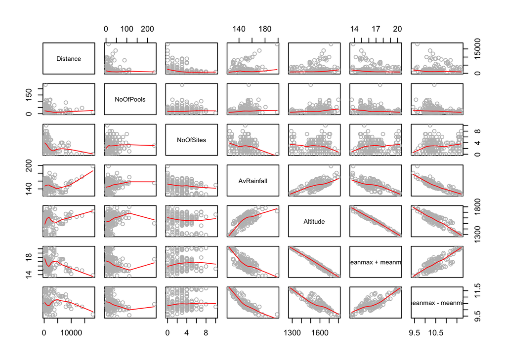

## Logistic multiple regression

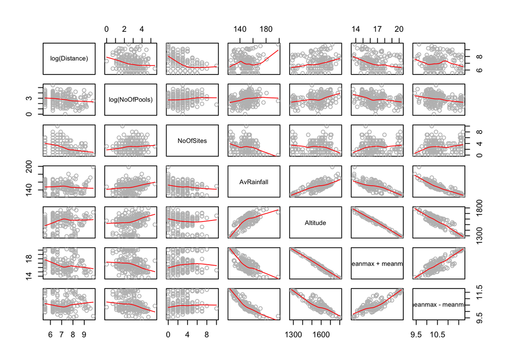

## Logistic multiple regression

```
##
## Call:
## glm(formula = pres.abs ~ log(distance) + log(NoOfPools) + NoOfSites +
##     avrain + I(meanmax + meanmin) + I(meanmax - meanmin), family = binomial,
##     data = frogs)
##
## Deviance Residuals:
##     Min       1Q   Median       3Q      Max
## -1.9763  -0.7189  -0.2786   0.7970   2.5745
##
## Coefficients:
##                        Estimate Std. Error z value Pr(>|z|)
## (Intercept)          18.2688999 16.1381912   1.132  0.25762
## log(distance)        -0.7583198  0.2558117  -2.964  0.00303 **
## log(NoOfPools)        0.5708953  0.2153335   2.651  0.00802 **
## NoOfSites            -0.0036201  0.1061469  -0.034  0.97279
## avrain                0.0007003  0.0411710   0.017  0.98643
## I(meanmax + meanmin)  1.4958055  0.3153152   4.744  2.1e-06 ***
## I(meanmax - meanmin) -3.8582668  1.2783921  -3.018  0.00254 **
## ---
## Signif. codes:  0 '***' 0.001 '**' 0.01 '*' 0.05 '.' 0.1 ' ' 1
##
## (Dispersion parameter for binomial family taken to be 1)
##
##     Null deviance: 279.99  on 211  degrees of freedom
## Residual deviance: 197.65  on 205  degrees of freedom
## AIC: 211.65
##
## Number of Fisher Scoring iterations: 5
```

## Logistic multiple regression

```
##
## Call:
## glm(formula = pres.abs ~ log(distance) + log(NoOfPools) + I(meanmax +
##     meanmin) + I(meanmax - meanmin), family = binomial)
##
## Deviance Residuals:
##     Min       1Q   Median       3Q      Max
## -1.9753  -0.7224  -0.2780   0.7974   2.5736
##
## Coefficients:
##                      Estimate Std. Error z value Pr(>|z|)
## (Intercept)           18.5268     5.2673   3.517 0.000436 ***
## log(distance)         -0.7547     0.2261  -3.338 0.000844 ***
## log(NoOfPools)         0.5707     0.2152   2.652 0.007999 **
## I(meanmax + meanmin)   1.4985     0.3088   4.853 1.22e-06 ***
## I(meanmax - meanmin)  -3.8806     0.9002  -4.311 1.63e-05 ***
## ---
## Signif. codes:  0 '***' 0.001 '**' 0.01 '*' 0.05 '.' 0.1 ' ' 1
##
## (Dispersion parameter for binomial family taken to be 1)
##
##     Null deviance: 279.99  on 211  degrees of freedom
## Residual deviance: 197.66  on 207  degrees of freedom
## AIC: 207.66
##
## Number of Fisher Scoring iterations: 5
```

## Fitted values

```r
frogs.glm <- frogs %$% glm(pres.abs ~ log(distance) + log(NoOfPools)
                           + I(meanmax + meanmin) + I(meanmax - meanmin),
                           family = binomial)
frogs.glm %>% fitted() %>% head()
```

```
##         1         2         3         4         5         6
## 0.9416691 0.9259228 0.9029415 0.8119619 0.9314070 0.7278038
```

```r
frogs.glm %>% predict(type = "response") %>% head()
```

```
##         1         2         3         4         5         6
## 0.9416691 0.9259228 0.9029415 0.8119619 0.9314070 0.7278038
```

```r
frogs.glm %>% predict(type = "link") %>% head() # Scale of linear predictor
```

```
##         1         2         3         4         5         6
## 2.7815212 2.5256832 2.2303441 1.4628085 2.6085055 0.9835086
```

## Fitted values with approximate SE’s

```r
pred <- frogs.glm %>%
  predict(type = "link", se.fit = TRUE)
data.frame(fit = pred$fit, se = pred$se.fit) %>% head()
```

```
##         fit        se
## 1 2.7815212 0.6859612
## 2 2.5256832 0.4851882
## 3 2.2303441 0.4381720
## 4 1.4628085 0.4805175
## 5 2.6085055 0.5290599
## 6 0.9835086 0.3900549
```

## Confidence intervals for the $\beta$

```r
frogs.glm %>% confint()
```

```
##                           2.5 %     97.5 %
## (Intercept)           8.5807639 29.3392400
## log(distance)        -1.2157643 -0.3247928
## log(NoOfPools)        0.1628001  1.0106909
## I(meanmax + meanmin)  0.9219804  2.1385678
## I(meanmax - meanmin) -5.7299615 -2.1868793
```

```r
frogs.glm %>% coef()
```

```
##          (Intercept)        log(distance)       log(NoOfPools)
##           18.5268418           -0.7546587            0.5707174
## I(meanmax + meanmin) I(meanmax - meanmin)
##            1.4984905           -3.8805856
```

## Cross validating predictive power

```r
set.seed(123)
frogs.glm <- glm(pres.abs ~ log(distance) + log(NoOfPools),
                 family = binomial, data = frogs)
cv <- CVbinary(frogs.glm)
```

```
##
## Fold:  3 10 2 6 5 4 9 8 7 1
## Internal estimate of accuracy = 0.759
## Cross-validation estimate of accuracy = 0.745
```

The cross-validation measure is the proportion of predictions over the folds that are correct.

## Cross validating predictive power

```r
frogs.glm2 <- glm(pres.abs ~ log(distance) + log(NoOfPools)
                 + I(meanmax + meanmin) + I(meanmax - meanmin),
                 family = binomial, data = frogs)
cv <- CVbinary(frogs.glm2)
```

```
##
## Fold:  1 5 9 8 7 2 10 6 4 3
## Internal estimate of accuracy = 0.778
## Cross-validation estimate of accuracy = 0.778
```

## Cross validating predictive power

```r
frogs.glm2 <- glm(pres.abs ~ log(distance) + log(NoOfPools)
                 + I(meanmax + meanmin) + I(meanmax - meanmin),
                 family = binomial, data = frogs)
cv <- CVbinary(frogs.glm2, nfolds = 5)
```

```
##
## Fold:  3 2 4 5 1
## Internal estimate of accuracy = 0.778
## Cross-validation estimate of accuracy = 0.783
```